# Assignment 1 - MSDS 411 Summer 2018

```python
# Now, let's add some additional columns to the training data frame
#train1['LOG_TARGET_WINS'] = np.log(train1['TARGET_WINS']) #log response
#train1['SQRT_TARGET_WINS'] = np.sqrt(train1['TARGET_WINS']) #sqrt response

train1['LOG_TEAM_BASERUN_SB'] = np.log(train1['TEAM_BASERUN_SB']) #log baserun
train1['LOG_TEAM_PITCHING_BB'] = np.log(train1['TEAM_PITCHING_BB']) #log walks allowed
train1['LOG_TEAM_PITCHING_H'] = np.log(train1['TEAM_PITCHING_H']) #log hits allowed
train1['LOG_TEAM_PITCHING_HR'] = np.log(train1['TEAM_PITCHING_HR']) #log home runs allowed
#train1['TEAM_BATTING_1B'] = (train1['TEAM_BATTING_H'] - train1['TEAM_BATTING_HR'] - train1['TEAM_BATTING_2B'] - train1['TEAM_BATTING_3B']) #1B hits only

# train1['LOG_TEAM_BATTING_1B'] = np.log(train1['TEAM_BATTING_1B'])
# train1['LOG_TEAM_BATTING_2B'] = np.log(train1['TEAM_BATTING_2B'])
# train1['LOG_TEAM_BATTING_3B'] = np.log(train1['TEAM_BATTING_3B'])
# train1['LOG_TEAM_BATTING_HR'] = np.log(train1['TEAM_BATTING_HR'])
# train1['LOG_TEAM_BATTING_BB'] = np.log(train1['TEAM_BATTING_BB'])
```

```python
# Also add same predictor variable columns to the test data frame, do not add any of the new response vars (TARGET_WINS not included in test)
#test1['LOG_TEAM_BATTING_H'] = np.log(test1['TEAM_BATTING_H']) #log hitting pred var
#test1['SQRT_TEAM_BATTING_H'] = np.sqrt(test1['TEAM_BATTING_H']) #sqrt hitting pred var
#test1['TEAM_BATTING_1B'] = (test1['TEAM_BATTING_H'] - test1['TEAM_BATTING_HR'] - test1['TEAM_BATTING_2B'] - test1['TEAM_BATTING_3B']) #1B hits only

test1['LOG_TEAM_BASERUN_SB'] = np.log(test1['TEAM_BASERUN_SB']) #log baserun
test1['LOG_TEAM_PITCHING_BB'] = np.log(test1['TEAM_PITCHING_BB']) #log walks allowed
test1['LOG_TEAM_PITCHING_H'] = np.log(test1['TEAM_PITCHING_H']) #log hits allowed
test1['LOG_TEAM_PITCHING_HR'] = np.log(test1['TEAM_PITCHING_HR']) #log hoe runs allowed
```

```python
# Now let's verify new additions to train1 and test1 data frames
print(train1.info())
print(test1.info())
train1.describe()
```

```
<class 'pandas.core.frame.DataFrame'>
Int64Index: 2275 entries, 0 to 2275
Data columns (total 22 columns):
Unnamed: 0              2275 non-null int64
INDEX                   2275 non-null float64
TARGET_WINS             2275 non-null float64
TEAM_BATTING_H          2275 non-null float64
TEAM_BATTING_2B         2275 non-null float64
TEAM_BATTING_3B         2275 non-null float64
TEAM_BATTING_HR         2275 non-null float64
TEAM_BATTING_BB         2275 non-null float64
TEAM_BATTING_SO         2275 non-null float64
TEAM_BASERUN_SB         2275 non-null float64
TEAM_BASERUN_CS         2275 non-null float64
TEAM_BATTING_HBP        2275 non-null float64
TEAM_PITCHING_H         2275 non-null float64
TEAM_PITCHING_HR        2275 non-null float64
TEAM_PITCHING_BB        2275 non-null float64
TEAM_PITCHING_SO        2275 non-null float64
TEAM_FIELDING_E         2275 non-null float64
TEAM_FIELDING_DP        2275 non-null float64
LOG_TEAM_BASERUN_SB     2275 non-null float64
LOG_TEAM_PITCHING_BB    2275 non-null float64
LOG_TEAM_PITCHING_H     2275 non-null float64
LOG_TEAM_PITCHING_HR    2275 non-null float64
dtypes: float64(21), int64(1)
memory usage: 408.8 KB
None
<class 'pandas.core.frame.DataFrame'>
RangeIndex: 259 entries, 0 to 258
Data columns (total 21 columns):
Unnamed: 0              259 non-null int64
INDEX                   259 non-null float64
TEAM_BATTING_H          259 non-null float64
TEAM_BATTING_2B         259 non-null float64
TEAM_BATTING_3B         259 non-null float64
TEAM_BATTING_HR         259 non-null float64
TEAM_BATTING_BB         259 non-null float64
TEAM_BATTING_SO         259 non-null float64
TEAM_BASERUN_SB         259 non-null float64
TEAM_BASERUN_CS         259 non-null float64
TEAM_BATTING_HBP        259 non-null float64
TEAM_PITCHING_H         259 non-null float64
TEAM_PITCHING_HR        259 non-null float64
TEAM_PITCHING_BB        259 non-null float64
TEAM_PITCHING_SO        259 non-null float64
TEAM_FIELDING_E         259 non-null float64
TEAM_FIELDING_DP        259 non-null float64
LOG_TEAM_BASERUN_SB     259 non-null float64
LOG_TEAM_PITCHING_BB    259 non-null float64
LOG_TEAM_PITCHING_H     259 non-null float64
LOG_TEAM_PITCHING_HR    259 non-null float64
dtypes: float64(20), int64(1)
memory usage: 42.6 KB
None
```

|  | Unnamed: 0 | INDEX | TARGET_WINS | TEAM_BATTING_H | TEAM_BATTING_2B | TEAM_BATTING_3B | TEAM_BATTING_HR | TEAM_BATTING_BB | TEAM_BATTING_SO | TEAM_BASERUN_SB | ... | TEAM_PITCHING_H | TEAM_PITCHING_HR | TEAM_PITCHING_BB | TEAM_PITCHING_SO | TEAM_FIELDING_E | TEAM_FIELDING_DP | LOG_TEAM_BASERUN_SB | LOG_TEAM_PITCHING_BB | LOG_TEAM_PITCHING_H | LOG_TEAM_PITCHING_HR |
| --- | --- | --- | --- | --- | --- | --- | --- | --- | --- | --- | --- | --- | --- | --- | --- | --- | --- | --- | --- | --- | --- |
| count | 2275.000000 | 2275.000000 | 2275.000000 | 2275.000000 | 2275.000000 | 2275.000000 | 2275.000000 | 2275.000000 | 2275.000000 | 2275.000000 | ... | 2275.000000 | 2275.000000 | 2275.000000 | 2275.000000 | 2275.000000 | 2275.000000 | 2275.000000 | 2275.000000 | 2275.000000 | 2275.000000 |
| mean | 1137.468132 | 1268.429011 | 80.826374 | 1469.523956 | 241.293626 | 55.298582 | 100.269091 | 501.779341 | 740.335240 | 124.457799 | ... | 1769.418022 | 106.395794 | 553.250989 | 807.425786 | 232.313407 | 144.090563 | 4.629712 | 6.284006 | 7.401675 | 4.437703 |
| std | 657.311649 | 736.509087 | 15.664221 | 144.113466 | 46.758628 | 27.896579 | 60.013762 | 122.245998 | 233.017773 | 85.181257 | ... | 1327.302422 | 60.704261 | 165.989151 | 247.355617 | 173.657557 | 25.268314 | 0.622935 | 0.248253 | 0.301678 | 0.764496 |
| min | 0.000000 | 1.000000 | 12.000000 | 992.000000 | 69.000000 | 8.000000 | 3.000000 | 12.000000 | 66.000000 | 14.000000 | ... | 1137.000000 | 3.000000 | 119.000000 | 181.000000 | 65.000000 | 52.000000 | 2.639057 | 4.779123 | 7.036148 | 1.098612 |
| 25% | 568.500000 | 630.500000 | 71.000000 | 1383.000000 | 208.000000 | 34.000000 | 42.500000 | 451.000000 | 562.000000 | 67.000000 | ... | 1419.000000 | 52.000000 | 476.000000 | 633.000000 | 127.000000 | 128.049231 | 4.204693 | 6.165418 | 7.257708 | 3.951244 |
| 50% | 1137.000000 | 1270.000000 | 82.000000 | 1454.000000 | 238.000000 | 47.000000 | 102.000000 | 512.000000 | 729.000000 | 106.000000 | ... | 1518.000000 | 107.000000 | 537.000000 | 797.000000 | 159.000000 | 145.000000 | 4.663439 | 6.285998 | 7.325149 | 4.672829 |
| 75% | 1706.500000 | 1916.000000 | 92.000000 | 1537.500000 | 273.000000 | 72.000000 | 147.000000 | 580.000000 | 925.000000 | 151.000000 | ... | 1682.000000 | 150.000000 | 611.000000 | 957.000000 | 249.000000 | 161.500000 | 5.017280 | 6.415097 | 7.427739 | 5.010635 |
| max | 2275.000000 | 2535.000000 | 146.000000 | 2554.000000 | 458.000000 | 223.000000 | 264.000000 | 878.000000 | 1399.000000 | 697.000000 | ... | 30132.000000 | 343.000000 | 3645.000000 | 2344.000000 | 737.000000 | 228.000000 | 6.546785 | 8.201112 | 10.313343 | 5.837730 |

8 rows × 22 columns

[output not shown]

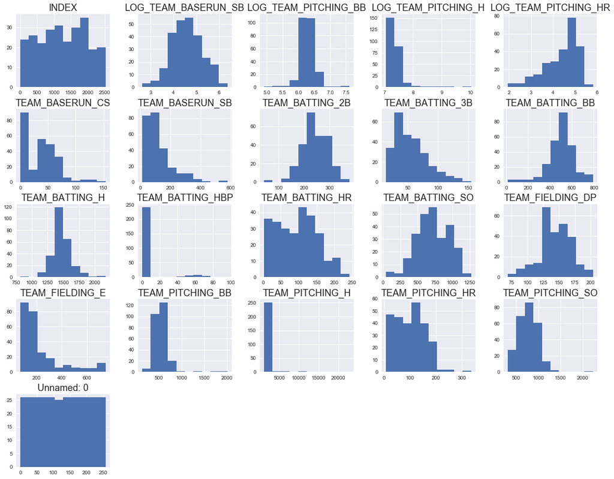

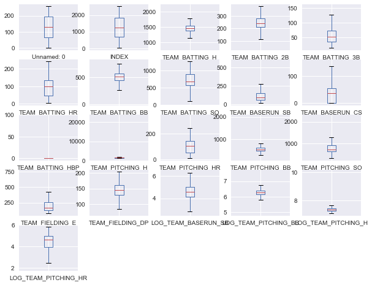

```python
# Now let's take another look at the cleaned and transformed dataset
test1.hist(figsize=(20,16))
test1.plot(kind= 'box' , subplots=True, layout=(5,5), sharex=False, sharey=False, figsize=(10,8))
```

```python
# This can be used to quickly change the variables for testing plots in this cell only
#myresponsevar = 'TARGET_WINS'
#myresponsevar = 'LOG_TARGET_WINS'

# goodhitting = ['TEAM_BATTING_HR', 'TEAM_BATTING_1B', 'TEAM_BATTING_2B', 'TEAM_BATTING_3B', 'TEAM_BATTING_BB', 'TEAM_BATTING_HBP']
# goodother = ['TEAM_PITCHING_SO', 'TEAM_FIELDING_DP', 'TEAM_BASERUN_SB']
# badpitching = ['TEAM_PITCHING_H', 'TEAM_PITCHING_HR', 'TEAM_PITCHING_BB']
# badoffense = ['TEAM_BATTING_SO', 'TEAM_BASERUN_CS']
# baddefense = ['TEAM_FIELDING_E']

# This was used for first Kaggle submissions 1-3
# myresponsevar = 'TARGET_WINS'
# mypredvars = ['TEAM_BATTING_HR', 'TEAM_BATTING_2B', 'TEAM_BATTING_3B', 'TEAM_BATTING_BB',
#               'TEAM_FIELDING_DP', 'TEAM_PITCHING_SO', 'TEAM_BATTING_SO', 'TEAM_BASERUN_CS', 'TEAM_FIELDING_E', 'TEAM_PITCHING_BB',
#               'TEAM_PITCHING_H', 'TEAM_PITCHING_HR']

# Use all vars - predictions4
# myresponsevar = 'TARGET_WINS'
# mypredvars = all

# New Test - predictions5
# myresponsevar = 'LOG_TARGET_WINS'
# mypredvars = ['TEAM_BATTING_1B', 'TEAM_BATTING_2B', 'TEAM_BATTING_3B', 'TEAM_BATTING_HR', 'TEAM_BATTING_BB',
#               'TEAM_PITCHING_BB', 'TEAM_FIELDING_E', 'TEAM_PITCHING_H']
#preds5 tried but not used
#mypredvars = ['TEAM_BATTING_H', 'TEAM_BATTING_1B', 'TEAM_BATTING_BB', 'TEAM_PITCHING_SO', 'TEAM_FIELDING_E', 'TEAM_PITCHING_H']
# mypredvars = ['TEAM_BATTING_HR', 'TEAM_BATTING_2B', 'TEAM_BATTING_3B', 'TEAM_BATTING_BB',
#               'TEAM_PITCHING_SO', 'TEAM_FIELDING_E', 'TEAM_PITCHING_BB', 'TEAM_PITCHING_H']

# Predictions 6
# myresponsevar = 'SQRT_TARGET_WINS'
# mypredvars = ['TEAM_BATTING_H', 'TEAM_BATTING_HR', 'TEAM_BATTING_3B', 'TEAM_BATTING_SO', 'TEAM_BATTING_HBP',
#               'TEAM_BASERUN_SB', 'TEAM_PITCHING_SO', 'TEAM_PITCHING_BB', 'TEAM_PITCHING_H', 'TEAM_FIELDING_DP', 'TEAM_FIELDING_E']

# Predictions 7
# myresponsevar = 'TARGET_WINS'
# mypredvars = ['TEAM_BATTING_HR', 'TEAM_BATTING_1B', 'TEAM_BATTING_2B', 'TEAM_BATTING_3B', 'TEAM_BATTING_HBP',
#               'TEAM_PITCHING_SO', 'TEAM_FIELDING_DP', 'TEAM_BASERUN_SB', 'TEAM_PITCHING_H', 'TEAM_PITCHING_BB']

# Predictions 8
# myresponsevar = 'TARGET_WINS'
# mypredvars = ['TEAM_BATTING_HR', 'TEAM_BATTING_1B', 'TEAM_BATTING_2B', 'TEAM_BATTING_3B', 'TEAM_BATTING_BB', 'TEAM_BATTING_HBP',
#               'TEAM_PITCHING_SO', 'TEAM_BASERUN_SB'] #all good items

# Predictions 9
# myresponsevar = 'TARGET_WINS'
# mypredvars = ['TEAM_BATTING_H', 'TEAM_BATTING_BB', 'TEAM_BATTING_SO', 'TEAM_FIELDING_DP', 'TEAM_PITCHING_SO',
#               'TEAM_FIELDING_E', 'TEAM_PITCHING_BB', 'TEAM_PITCHING_H', 'TEAM_PITCHING_HR']

# Predictions 10
# myresponsevar = 'TARGET_WINS'
# mypredvars = ['TEAM_BATTING_HR', 'TEAM_BATTING_1B', 'TEAM_BATTING_2B', 'TEAM_BATTING_3B',
#               'TEAM_FIELDING_DP', 'TEAM_PITCHING_SO', 'TEAM_BATTING_SO', 'TEAM_FIELDING_E', 'TEAM_PITCHING_BB',
#               'TEAM_PITCHING_H', 'TEAM_PITCHING_HR']

# Predictions 11 / 12
# myresponsevar = 'TARGET_WINS'
# mypredvars = ['TEAM_BATTING_HR', 'TEAM_BATTING_2B', 'TEAM_BATTING_3B', 'TEAM_BATTING_BB',
#               'TEAM_FIELDING_DP', 'TEAM_PITCHING_SO', 'TEAM_BATTING_SO', 'TEAM_BASERUN_CS', 'TEAM_FIELDING_E', 'TEAM_PITCHING_BB',
#               'TEAM_PITCHING_H', 'TEAM_PITCHING_HR']

# Predictions 13
# myresponsevar = 'TARGET_WINS'
# mypredvars = ['TEAM_BATTING_H', 'TEAM_BATTING_HR', 'TEAM_BATTING_2B', 'TEAM_BATTING_3B', 'TEAM_BATTING_BB', 'TEAM_BASERUN_SB',
#               'TEAM_FIELDING_DP', 'TEAM_PITCHING_SO', 'TEAM_BATTING_SO', 'TEAM_FIELDING_E', 'TEAM_PITCHING_BB',
#               'TEAM_PITCHING_H', 'TEAM_PITCHING_HR']

# Predictions 14
# myresponsevar = 'TARGET_WINS'
# mypredvars = ['TEAM_BATTING_HR', 'TEAM_BATTING_H', 'TEAM_BATTING_2B', 'TEAM_BATTING_3B', 'TEAM_BATTING_BB', 'LOG_TEAM_BASERUN_SB',
#               'TEAM_FIELDING_DP', 'TEAM_PITCHING_SO', 'TEAM_BATTING_SO', 'TEAM_FIELDING_E', 'LOG_TEAM_PITCHING_BB',
#               'LOG_TEAM_PITCHING_H', 'LOG_TEAM_PITCHING_HR']

# Predictions 15
myresponsevar = 'TARGET_WINS'
mypredvars = ['TEAM_BATTING_H', 'TEAM_BATTING_BB', 'TEAM_FIELDING_DP', 'TEAM_PITCHING_SO', 'TEAM_BATTING_SO',
              'TEAM_FIELDING_E', 'TEAM_PITCHING_BB', 'TEAM_PITCHING_H', 'TEAM_PITCHING_HR']


# Other comparison tests used - remove before submitting
#mypredvars = ['TEAM_BATTING_H', 'LOG_TEAM_BATTING_H', 'SQRT_TEAM_BATTING_H']
# mypredvars = ['TEAM_BATTING_H', 'TEAM_BATTING_HR', 'TEAM_BATTING_2B', 'TEAM_BATTING_3B', 'TEAM_BATTING_BB', 'TEAM_BASERUN_SB',
#               'TEAM_FIELDING_DP', 'TEAM_PITCHING_SO', 'TEAM_BATTING_SO', 'TEAM_BASERUN_CS', 'TEAM_FIELDING_E', 'TEAM_PITCHING_BB',
#               'TEAM_PITCHING_H', 'TEAM_PITCHING_HR']

predstr = ''
for i in mypredvars:
    predstr = predstr + ' + ' + str(i)

# Now build the string for the linear model
modelstr = myresponsevar + predstr
modelstr = modelstr.replace('+', '~', 1) #replace only the first instance
print(modelstr) # this is the string replesenting the MLR model for use below
```

```
TARGET_WINS ~ TEAM_BATTING_H + TEAM_BATTING_BB + TEAM_FIELDING_DP + TEAM_PITCHING_SO + TEAM_BATTING_SO + TEAM_FIELDING_E + TEAM_PITCHING_BB + TEAM_PITCHING_H + TEAM_PITCHING_HR
```

```python
# Section 2 Results:
```

### >>> Section 3 - Model Building

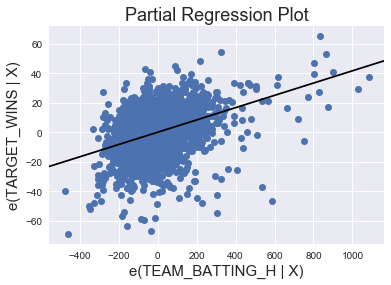

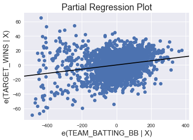

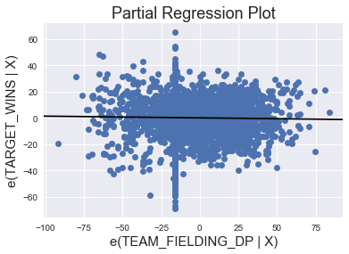

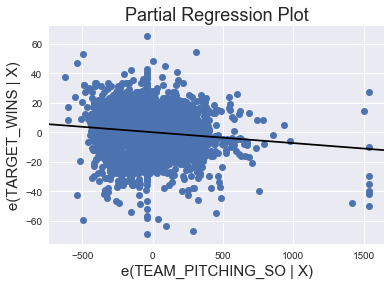

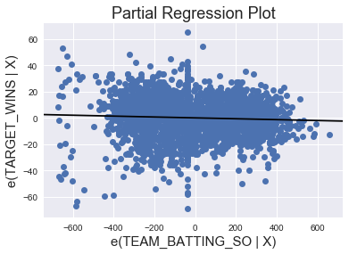

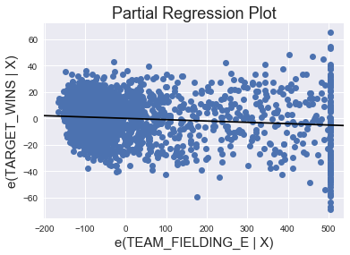

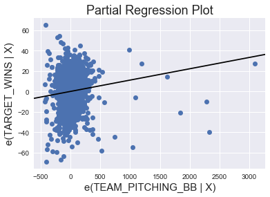

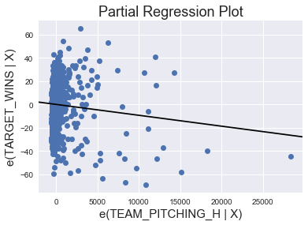

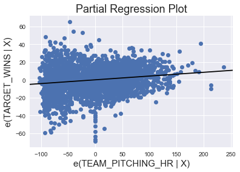

```python
#Just in case there are some variables that are highly correlated look at some scatter plots
# # option 1
# for i in mypredvars:
#     train1.plot.scatter(y=myresponsevar, x=i, s=None, c=None, marker=None, cmap=None, norm=None, vmin=None, vmax=None, alpha=None,
#                         linewidths=None, verts=None, edgecolors=None )

# option 2 - shown with regr line
for i in mypredvars:
    sm.graphics.plot_partregress(myresponsevar, i, [], data = train1, obs_labels = False)
```

```python
#From sample code
#Take a look at a possible model
print(modelstr + str('\n'))

#previous tests
#regres1 = smf.ols('LOG_TARGET_WINS ~ TEAM_BATTING_H', data = train1)
#regres1 = smf.ols('TARGET_WINS ~ TEAM_BATTING_H + TEAM_BATTING_BB', data = train1)
#regres1 = smf.ols('TARGET_WINS ~ TEAM_BATTING_2B + TEAM_BATTING_3B + TEAM_BATTING_HR + TEAM_BATTING_BB + TEAM_BASERUN_SB', data = train1)
#regres1 = smf.ols('LOG_TARGET_WINS ~ TEAM_BATTING_H + TEAM_BATTING_BB + TEAM_BASERUN_SB + TEAM_FIELDING_DP', data = train1)
#regres1 = smf.ols('TARGET_WINS ~ TEAM_BATTING_HR + TEAM_BATTING_HBP + TEAM_BATTING_BB + TEAM_BASERUN_SB', data = train1)

'''
Function: fit model
Takes a model string & dataframe, runs the linear model calc and returns the fit result
'''
def fit_model(fullmodelstr, dataset):
    return smf.ols(fullmodelstr, data = dataset).fit()

#     regres1 = smf.ols(...
#     fit1 = regres1.fit()
#     return fit1
```

```
TARGET_WINS ~ TEAM_BATTING_H + TEAM_BATTING_BB + TEAM_FIELDING_DP + TEAM_PITCHING_SO + TEAM_BATTING_SO + TEAM_FIELDING_E + TEAM_PITCHING_BB + TEAM_PITCHING_H + TEAM_PITCHING_HR
```

```python
# Run the model
result1 = fit_model(modelstr, train1)
#print(dir(result1)) #use this if you want to see teh available attributes
print (result1.summary())
print (result1.conf_int())
#dir(result1) lists other print options

# # Now run pred model on the test1 set
# predictions = result1.predict(test1)
# print(predictions)
```

```
                            OLS Regression Results
==============================================================================
Dep. Variable:            TARGET_WINS   R-squared:                       0.276
Model:                            OLS   Adj. R-squared:                  0.274
Method:                 Least Squares   F-statistic:                     96.17
Date:                Sun, 15 Jul 2018   Prob (F-statistic):          3.16e-152
Time:                        21:14:30   Log-Likelihood:                -9118.8
No. Observations:                2275   AIC:                         1.826e+04
Df Residuals:                    2265   BIC:                         1.831e+04
Df Model:                           9
Covariance Type:            nonrobust
====================================================================================
                       coef    std err          t      P>|t|      [0.025      0.975]
------------------------------------------------------------------------------------
Intercept           15.9986      5.093      3.141      0.002       6.010      25.987
TEAM_BATTING_H       0.0545      0.003     20.547      0.000       0.049       0.060
TEAM_BATTING_BB      0.0077      0.006      1.362      0.173      -0.003       0.019
TEAM_FIELDING_DP    -0.1465      0.014    -10.839      0.000      -0.173      -0.120
TEAM_PITCHING_SO    -0.0002      0.003     -0.057      0.955      -0.007       0.006
TEAM_BATTING_SO      0.0003      0.004      0.089      0.929      -0.007       0.008
TEAM_FIELDING_E     -0.0129      0.003     -4.388      0.000      -0.019      -0.007
TEAM_PITCHING_BB     0.0133      0.004      3.570      0.000       0.006       0.021
TEAM_PITCHING_H     -0.0028      0.000     -7.101      0.000      -0.004      -0.002
TEAM_PITCHING_HR     0.0224      0.008      2.681      0.007       0.006       0.039
==============================================================================
Omnibus:                       17.570   Durbin-Watson:                   1.070
Prob(Omnibus):                  0.000   Jarque-Bera (JB):               24.991
Skew:                          -0.062   Prob(JB):                     3.74e-06
Kurtosis:                       3.498   Cond. No.                     5.17e+04
==============================================================================

Warnings:
[1] Standard Errors assume that the covariance matrix of the errors is correctly specified.
[2] The condition number is large, 5.17e+04. This might indicate that there are
strong multicollinearity or other numerical problems.
                         0          1
Intercept         6.010350  25.986841
TEAM_BATTING_H    0.049332   0.059742
TEAM_BATTING_BB  -0.003407   0.018898
TEAM_FIELDING_DP -0.172964  -0.119965
TEAM_PITCHING_SO -0.006651   0.006277
TEAM_BATTING_SO  -0.007257   0.007946
TEAM_FIELDING_E  -0.018600  -0.007111
TEAM_PITCHING_BB  0.005986   0.020577
TEAM_PITCHING_H  -0.003568  -0.002024
TEAM_PITCHING_HR  0.006018   0.038778
```

```python
'''
This code is for performing a step-wise forward selection on the defined model.
Input: modelstr
Output: string with best AIC/BIC scores
Descr: Uses the sample code for smf.ols fit to fit the model and obtain the summary
'''

def stepwise_fwd_selection(fullmodelstr, dataset):
    #first sep string into components and save the response
    respons = fullmodelstr[:fullmodelstr.find(' ~')]
    allpredictors = fullmodelstr[fullmodelstr.find(' ~')+3:]
    print(allpredictors)

    #ok, now split preds based on number of '+' char found in allpredictors string + 1
    num_of_preds = 0
    if(fullmodelstr.count('+') < 1):
        num_of_preds = 1
    else:
        num_of_preds = fullmodelstr.count('+') + 1

    #separate out preditors from the string
    preds = []
    tmpstr = allpredictors
    for i in list(range(num_of_preds)):
        #print('tmpstr is: ' + str(tmpstr))
        if(tmpstr.count('+') < 1):
            preds.append(tmpstr)
        else:
            preds.append(tmpstr[:tmpstr.find(' +')])
        tmpstr = tmpstr[tmpstr.find(' +')+3:]

    #ok, now we need to run the linear model for each iteration starting with the first and sequentially adding all predictors
    # fit the partial model for each step starting
    adjR2 = []
    aic = []
    bic = []

    steppreds = ''
    for i in preds:
        stepmodelstr = str(respons) + ' ~ ' + steppreds + str(i)
        stepresult = fit_model(stepmodelstr, train1)
        steppreds = steppreds + str(i) + ' + '
        adjR2.append(stepresult.rsquared_adj)
        aic.append(stepresult.aic)
        bic.append(stepresult.bic)
        #print (stepresult.summary())
        #print('+++++++++++++++++++++++++++++++++++++++++\n\n')

    print(adjR2)
#     print('AIC values: ' + str(aic))
#     print('BIC values: ' + str(bic))
#     return respons, preds
    return np.argmax(adjR2), np.argmin(aic), np.argmin(bic)

# Next try it out
output1, output2, output3 = stepwise_fwd_selection(modelstr, None)
print(output1)
print(output2)
print(output3)
```

```
TEAM_BATTING_H + TEAM_BATTING_BB + TEAM_FIELDING_DP + TEAM_PITCHING_SO + TEAM_BATTING_SO + TEAM_FIELDING_E + TEAM_PITCHING_BB + TEAM_PITCHING_H + TEAM_PITCHING_HR
[0.14655382167725062, 0.2123131984076223, 0.2369548372653515, 0.23854849486451457, 0.24667101117963408, 0.2573591235050038, 0.25753110926884104, 0.2716268712075054, 0.2736112160019061]
8
8
7
```

The sections that follow are a way to perform R-like model output graphs in Python that mimic the lm plot functionality

A huge shout-out to @emredjan for the original blog post about R-to-Python functionality translation [here](https://medium.com/@emredjan/emulating-r-regression-plots-in-python-43741952c034)

```python
# fitted values (need a constant term for intercept)
model_fitted_y = result1.fittedvalues

# model residuals
model_residuals = result1.resid

# normalized residuals
model_norm_residuals = result1.get_influence().resid_studentized_internal

# absolute squared normalized residuals
model_norm_residuals_abs_sqrt = np.sqrt(np.abs(model_norm_residuals))

# absolute residuals
model_abs_resid = np.abs(model_residuals)

# leverage, from statsmodels internals
model_leverage = result1.get_influence().hat_matrix_diag

# cook's distance, from statsmodels internals
model_cooks = result1.get_influence().cooks_distance[0]
```

```python
# Print each plot output
```

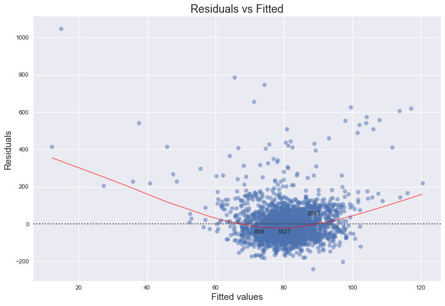

```python
#1 Residual Plot
plot_lm_1 = plt.figure(1)
plot_lm_1.set_figheight(8)
plot_lm_1.set_figwidth(12)

plot_lm_1.axes[0] = sns.residplot(model_fitted_y, 'TEAM_BATTING_H', data = train1,
                          lowess=True,
                          scatter_kws={'alpha': 0.5},
                          line_kws={'color': 'red', 'lw': 1, 'alpha': 0.8})

plot_lm_1.axes[0].set_title('Residuals vs Fitted')
plot_lm_1.axes[0].set_xlabel('Fitted values')
plot_lm_1.axes[0].set_ylabel('Residuals')

# annotations
abs_resid = model_abs_resid.sort_values(ascending=False)
abs_resid_top_3 = abs_resid[:3]

for i in abs_resid_top_3.index:
    plot_lm_1.axes[0].annotate(i,
                               xy=(model_fitted_y[i],
                                   model_residuals[i]));
```

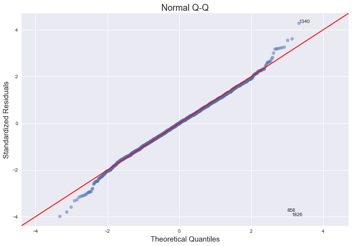

```python
#2 Q-Q Plot
QQ = ProbPlot(model_norm_residuals)
plot_lm_2 = QQ.qqplot(line='45', alpha=0.5, color='#4C72B0', lw=1)

plot_lm_2.set_figheight(8)
plot_lm_2.set_figwidth(12)

plot_lm_2.axes[0].set_title('Normal Q-Q')
plot_lm_2.axes[0].set_xlabel('Theoretical Quantiles')
plot_lm_2.axes[0].set_ylabel('Standardized Residuals');

# annotations
abs_norm_resid = np.flip(np.argsort(np.abs(model_norm_residuals)), 0)
abs_norm_resid_top_3 = abs_norm_resid[:3]

for r, i in enumerate(abs_norm_resid_top_3):
    plot_lm_2.axes[0].annotate(i,
                               xy=(np.flip(QQ.theoretical_quantiles, 0)[r],
                                   model_norm_residuals[i]));
```

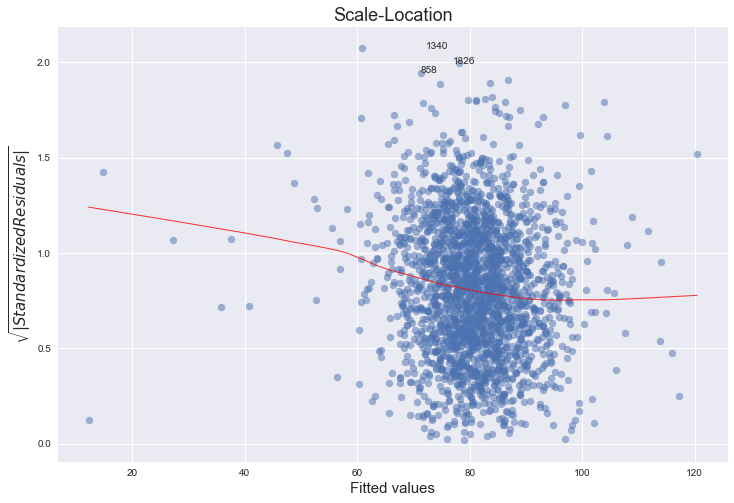

```python
#3 Scale-Location Plot

plot_lm_3 = plt.figure(3)
plot_lm_3.set_figheight(8)
plot_lm_3.set_figwidth(12)

plt.scatter(model_fitted_y, model_norm_residuals_abs_sqrt, alpha=0.5)
sns.regplot(model_fitted_y, model_norm_residuals_abs_sqrt,
            scatter=False,
            ci=False,
            lowess=True,
            line_kws={'color': 'red', 'lw': 1, 'alpha': 0.8})

plot_lm_3.axes[0].set_title('Scale-Location')
plot_lm_3.axes[0].set_xlabel('Fitted values')
plot_lm_3.axes[0].set_ylabel('$\sqrt{|Standardized Residuals|}$');

# annotations
abs_sq_norm_resid = np.flip(np.argsort(model_norm_residuals_abs_sqrt), 0)
abs_sq_norm_resid_top_3 = abs_sq_norm_resid[:3]

for i in abs_norm_resid_top_3:
    plot_lm_3.axes[0].annotate(i,
                               xy=(model_fitted_y[i],
                                   model_norm_residuals_abs_sqrt[i]));
```

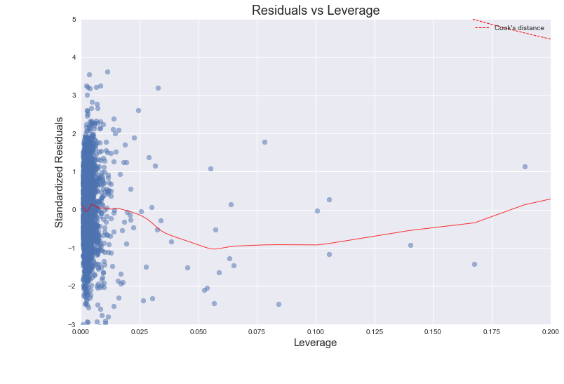

```python
#4 Leverage Plot
plot_lm_4 = plt.figure(4)
plot_lm_4.set_figheight(8)
plot_lm_4.set_figwidth(12)

plt.scatter(model_leverage, model_norm_residuals, alpha=0.5)
sns.regplot(model_leverage, model_norm_residuals,
            scatter=False,
            ci=False,
            lowess=True,
            line_kws={'color': 'red', 'lw': 1, 'alpha': 0.8})

plot_lm_4.axes[0].set_xlim(0, 0.20)
plot_lm_4.axes[0].set_ylim(-3, 5)
plot_lm_4.axes[0].set_title('Residuals vs Leverage')
plot_lm_4.axes[0].set_xlabel('Leverage')
plot_lm_4.axes[0].set_ylabel('Standardized Residuals')

# annotations
leverage_top_3 = np.flip(np.argsort(model_cooks), 0)[:3]

for i in leverage_top_3:
    plot_lm_4.axes[0].annotate(i,
                               xy=(model_leverage[i],
                                   model_norm_residuals[i]))

# shenanigans for cook's distance contours
def graph(formula, x_range, label=None):
    x = x_range
    y = formula(x)
    plt.plot(x, y, label=label, lw=1, ls='--', color='red')

p = len(result1.params) # number of model parameters

graph(lambda x: np.sqrt((0.5 * p * (1 - x)) / x),
      np.linspace(0.001, 0.200, 50),
      'Cook\'s distance') # 0.5 line
graph(lambda x: np.sqrt((1 * p * (1 - x)) / x),
      np.linspace(0.001, 0.200, 50)) # 1 line
plt.legend(loc='upper right');
```

### >>> Section 4 - Select Model

```python
print(modelstr)

#Take a look at the final model
regres_final = smf.ols(modelstr , data = train1)
result_final = regres_final.fit()
print (result_final.summary())
print (result_final.conf_int())
#dir(result) lists other print options

final_predictions = result_final.predict(test1)
print(final_predictions)
```

```
TARGET_WINS ~ TEAM_BATTING_H + TEAM_BATTING_BB + TEAM_FIELDING_DP + TEAM_PITCHING_SO + TEAM_BATTING_SO + TEAM_FIELDING_E + TEAM_PITCHING_BB + TEAM_PITCHING_H + TEAM_PITCHING_HR
                            OLS Regression Results
==============================================================================
Dep. Variable:            TARGET_WINS   R-squared:                       0.276
Model:                            OLS   Adj. R-squared:                  0.274
Method:                 Least Squares   F-statistic:                     96.17
Date:                Sun, 15 Jul 2018   Prob (F-statistic):          3.16e-152
Time:                        21:15:10   Log-Likelihood:                -9118.8
No. Observations:                2275   AIC:                         1.826e+04
Df Residuals:                    2265   BIC:                         1.831e+04
Df Model:                           9
Covariance Type:            nonrobust
====================================================================================
                       coef    std err          t      P>|t|      [0.025      0.975]
------------------------------------------------------------------------------------
Intercept           15.9986      5.093      3.141      0.002       6.010      25.987
TEAM_BATTING_H       0.0545      0.003     20.547      0.000       0.049       0.060
TEAM_BATTING_BB      0.0077      0.006      1.362      0.173      -0.003       0.019
TEAM_FIELDING_DP    -0.1465      0.014    -10.839      0.000      -0.173      -0.120
TEAM_PITCHING_SO    -0.0002      0.003     -0.057      0.955      -0.007       0.006
TEAM_BATTING_SO      0.0003      0.004      0.089      0.929      -0.007       0.008
TEAM_FIELDING_E     -0.0129      0.003     -4.388      0.000      -0.019      -0.007
TEAM_PITCHING_BB     0.0133      0.004      3.570      0.000       0.006       0.021
TEAM_PITCHING_H     -0.0028      0.000     -7.101      0.000      -0.004      -0.002
TEAM_PITCHING_HR     0.0224      0.008      2.681      0.007       0.006       0.039
==============================================================================
Omnibus:                       17.570   Durbin-Watson:                   1.070
Prob(Omnibus):                  0.000   Jarque-Bera (JB):               24.991
Skew:                          -0.062   Prob(JB):                     3.74e-06
Kurtosis:                       3.498   Cond. No.                     5.17e+04
==============================================================================

Warnings:
[1] Standard Errors assume that the covariance matrix of the errors is correctly specified.
[2] The condition number is large, 5.17e+04. This might indicate that there are
strong multicollinearity or other numerical problems.
                         0          1
Intercept         6.010350  25.986841
TEAM_BATTING_H    0.049332   0.059742
TEAM_BATTING_BB  -0.003407   0.018898
```

[output cut: 54 more lines]

```
245    86.411135
246    81.215825
247    83.618347
248    72.814952
249    79.267620
250    82.066755
251    66.914092
252    91.731012
253    40.391720
254    70.366462
255    78.182756
256    81.482667
257    80.083648
258    78.827314
Length: 259, dtype: float64
```

### >>> Section 5 - Deployed Model

```python
# TODO: Write out model equation in explicit form
# Note: Just disply it here no code to run - copy to report.
modelstr
```

```
'TARGET_WINS ~ TEAM_BATTING_H + TEAM_BATTING_BB + TEAM_FIELDING_DP + TEAM_PITCHING_SO + TEAM_BATTING_SO + TEAM_FIELDING_E + TEAM_PITCHING_BB + TEAM_PITCHING_H + TEAM_PITCHING_HR'
```

### >>> Section 6 - Scored Data File

```python
# From provided sample code

#Convert the array predictions to a data frame then merge with the index for the test data to create your file
d = {'P_TARGET_WINS': round(final_predictions, 1)}
#df1 = testdf[['INDEX']]
df1 = pd.to_numeric(testdf['INDEX'], downcast = 'integer').to_frame()

df2 = pd.DataFrame(data = d)
output_file = pd.concat([df1,df2], axis = 1, join_axes = [df1.index])

#Submit your file as csv using the following code to save on your computer
#output_file.to_csv('output/predictions.csv', index = False)
#output_file.to_csv('output/andrew_knight_predictions1.csv') # This file was my first submission to Kaggle on 20180710-0858 - failed
#output_file.to_csv('output/andrew_knight_predictions2.csv', index = False) # Second attempt on 20180710-0928 still has formatting issues - failed
#output_file.to_csv('output/andrew_knight_predictions3.csv', index = False) # Third attempt on 20180710 - THIS WORKED FINALLY!

#new test
#output_file.to_csv('output/andrew_knight_predictions4.csv', index = False) # First attempt on 20180711-2155
#output_file.to_csv('output/andrew_knight_predictions5.csv', index = False) # Using LOG_TARGET_WINS on 20180711-2315
#output_file.to_csv('output/andrew_knight_predictions6.csv', index = False) # Using SQRT_TARGET_WINS on 20180711-2332
#output_file.to_csv('output/andrew_knight_predictions7.csv', index = False) # Preds7 subm on 20180712-0048
#output_file.to_csv('output/andrew_knight_predictions8.csv', index = False) # Preds8 subm on 20180712-0053
#output_file.to_csv('output/andrew_knight_predictions9.csv', index = False) # Preds9 subm on 20180712-0152 and -2256
#output_file.to_csv('output/andrew_knight_predictions10.csv', index = False) # Pred10 subm on 20180712-2301
#output_file.to_csv('output/andrew_knight_predictions11.csv', index = False) # Pred11 subm on 20180712-2311
#output_file.to_csv('output/andrew_knight_predictions12.csv', index = False) # Pred12 subm on 20180712-2318
#output_file.to_csv('output/andrew_knight_predictions13.csv', index = False) # Pred13 subm on 20180712-2326
#output_file.to_csv('output/andrew_knight_predictions14.csv', index = False) # Pred14
output_file.to_csv('output/andrew_knight_predictions15.csv', index = False) # Pred15
```

```python
# sanity check section
```

### Submit to Kaggle

Use the following to submit

`kaggle competitions submit -c moneyball-411-summer-2018 -f submission.csv -m "Message"`

### Useful References

[Baseball stats](https://www.baseball-reference.com/)

[sklearn linear models](http://scikit-learn.org/stable/modules/linear_model.html)

[stats models package fitting models info](https://www.statsmodels.org/stable/example_formulas.html#ols-regression-using-formulas)